# Solución tarea 1. Fundamentos

## Matemáticas Discretas

### Fundación Universitaria Konrad Lorenz

### Punto 1:

🇺🇸 In a class of 50 college freshmen, 30 are studying C++, 25 are studying Java, and 10 are studying both languages. How many freshmen are studying either computer languages?

🇨🇴 En una clase de 50 estudiantes de primer año, 30 están estudiando C++, 25 estan estudiando Java, y 10 estan estudiando los dos lenguajes. ¿Cuántos estuadiantes de primer año están estudiando al menos uno de los idiomas?

**Solución:**

Primero definiremos los conjuntos del problema y sus cardinales:

- $U=\{x:x\text{ es estudiante de primer año}\},$
- $A=\{x\in U:x\text{ estudia C++}\},$
- $B=\{x\in U:x\text{ estudia Java}\}.$

Y $|A|=30$, $|B|=25$, y $|U|=50$. Entonces el diagrama de Venn será:

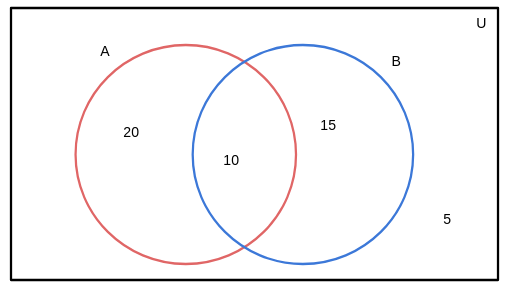

```python
from IPython.display import Image
Image("punto1.png")
```

Finalmente, diremos que el número de estudiante que están estudiando al menos un idioma es **45.**

### Punto 2:

🇺🇸 An AND gate in an ASIC (Application Specific Integrates Circuit) has two imputes: $I_1$, $I_2$ and one output $O$. Such an AND gate can have any or all of the following defects:

- $D_1$: The input $I_1$ is stuck at $0$,
- $D_2$: The input $I_2$ is stuck at $0$,
- $D_3$: The input $O$ is stuck at $1$.

For a sample of 100 such gates we let $A$, $B$ and $C$ be the subsets (of these 100 gates) having defects $D_1$, $D_2$ and $D_3$, respectively. With $|A| = 23$, $|B| = 26$, $|C| = 30$, $|A∩B| = 7$, $|A ∩ C| = 8$, $|B ∩ C| = 10$ and $|A ∩ B ∩ C| = 3$. How many gates in the sample have at least one of the defects $D_1$, $D_2$ and $D_3$?

🇨🇴 Una puerta AND en ASIC (Application Specific Integrates Circuit) tiene dos entradas: $I_1$, $I_2$ y una salida $O$. Talque una puerta AND tiene alguno de los siguientes defectos:

- $D_1$: La entrada $I_1$ falla en $0$,
- $D_2$: La entrada $I_2$ falla en $0$,
- $D_3$: La entrada $O$ falla en $1$.

Por ejemplo, una muestra para 100 puertas vamos a tomar los subconjuntos $A$, $B$ y $C$ (de las 100 puertas) que tienen los defectos $D_1$, $D_2$ y $D_3$, respectivamente. Con $|A| = 23$, $|B| = 26$, $|C| = 30$, $|A∩B| = 7$, $|A ∩ C| = 8$, $|B ∩ C| = 10$ y $|A ∩ B ∩ C| = 3$. ¿Cuántas puertas en la muestra tiene al menos uno de los defectos $D_1$, $D_2$ y $D_3$?

**Solución:**

Primero definiremos los conjuntos del problema:

- $U=\{x:x\text{ es una puerta de la muestra}\},$
- $A=\{x\in U:x\text{ es una puerta con el defecto }D_1\},$
- $B=\{x\in U:x\text{ es una puerta con el defecto }D_2\},$
- $C=\{x\in U:x\text{ es una puerta con el defecto }D_3\}.$

Y los cardinales dados por el problema son:

- $|A| = 23$,
- $|B| = 26$,
- $|C| = 30$,
- $|A∩B| = 7$,
- $|A ∩ C| = 8$,
- $|B ∩ C| = 10$,
- $|A ∩ B ∩ C| = 3$.

Con lo cual tendremos el siguiente diagrama de Venn:

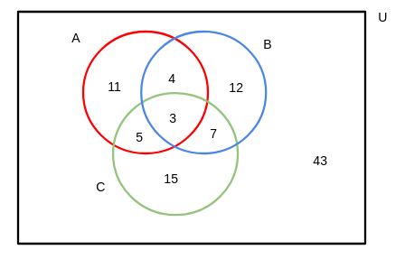

```python
from IPython.display import Image
Image("punto2.png")
```

Finalmente, diremos que el número de puertas que tiene al menos uno de los defectos es **57.**

### Punto 3:

🇺🇸 List all subsets of $\{0, 1, 3\}$. How many do you get?

🇨🇴 Liste todos los subconjuntos de $\{0, 1, 3\}$. ¿Cuántos hay?

```python
PX=Subsets([0,1,3])
print(set(PX))
print("El cardinal del conjunto es: ",PX.cardinality())
```

```
{{0, 3}, {0, 1}, {3}, {1}, {}, {0, 1, 3}, {1, 3}, {0}}
El cardinal del conjunto es:  8
```

### Punto 4:

🇺🇸 Define a set of which both $\{1,3,4\}$ and $\{0,3,5\}$ are subsets. Find such a set with the smallest possible number. What is the connection between the notion of the union sets and this exercise?

🇨🇴 Defina un conjunto para el cual $\{1,3,4\}$ y $\{0,3,5\}$ sean subconjuntos. Además, ese conjunto debe ser el mas pequeño posible. Luego diga, ¿Cuál es la relación entre la noción de unión en conjuntos y el ejercicio de este punto?

**Solución:**

Si tomamos $\{1,3,4\}\cup \{0,3,5\}=\{0,1,3,4,5\}$ generamos el más pequeno que contine a ambos conjuntos por separado. Y en general sean $A$ y $B$ conjuntos, el conjunto más pequeño que los contiene es $A\cup B$.

### Punto 5:

🇺🇸 We form the union of two sets. We know that one of them has $n$ elements and the other has $m$ elements.What can we infer bout the cardinality of they union?

🇨🇴 Hagamos la unión de dos conjuntos. Sabemos que uno de los conjuntos tiene $n$ elementos y el otro tiene $m$ elementos. ¿ Qué puede inferir sobre la cardinalidad de la unión de estos dos conjuntos?

**Solución:**

Sean $A$ y $B$ conjuntos tales que $|A|=n$ y $|B|=m$, entonces $$|A\cup B|=|A|+|B|-|A\cap B|.$$

### Punto 6:

🇺🇸 Give an example of the relation: "Let $A$ be a set. The symbol $\subset $ represents a relation on $\mathcal{P}(A)$, where $P, Q \in \mathcal{P}(A)$ are related if and only if $P \subset Q$." which is express in terms of sets as:

$$\subset =\left\{\left(P,Q\right)\in \mathcal{P}(A)\times\mathcal{P}(A) :P \subset Q\right\}.$$

With the example determine if the relation is an order or an equivalence relation.

🇨🇴 De un ejemplo de la relación: "Sea $A$ un conjunto. El símbolo $\subset$ representa una relación sobr el conjunto $\mathcal{P}(A)$, donde $P, Q \in \mathcal{P}(A)$ se relacionan si y solo si $P \subset Q$." La cual se expresa por comprensión como sigue:

$$\subset=\left\{\left(P,Q\right)\in \mathcal{P}(A)\times\mathcal{P}(A) :P \subset Q\right\}.$$

Con el ejemplo determine si la relación es de orden o es de equivalencia.

**Solución**

*Nota:* La demostración no se pedía en la tarea pero se incluye en la solución con el fin de mostrar que este es un hecho que se cumple para cualquier conjunto independiente de sus elementos.

Se arrancará por hacer una demostración general para ver que para cualquier conjunto, la relación de contenencia sobre las particiones del mismo es diempre una relación de orden, es decir, cumple ser reflexiva, antisimétrica y transitiva.

Sea $A$ un conjunto y partes de $A$ el conjunto definido como sigue $\mathcal{P}(A)=\{X: X\subset A\}$.

1. Reflexividad: **P.D -->** Para todo $X\subset A$ la pareja $(X,X)$ está en la relación.

✍️ Sea $X\subset A$, como $X=X$ en particular $X\subset A$ entonces $(X,X)$ está en la relación.

1. Antisimetría: **P.D -->** Para toda pareja $(X,Y)$ en la relación, tal que $X\neq Y$ (i.e. $X\not\subset Y$ or $Y\not\subset X$), la pareja $(Y,X)$ no está en la relación.

✍️ Su pongamos que para una pareja $(X,Y)$ tal que $X\neq Y$ la pareja $(Y,X)$ está en la relación. Esto quiere decir por un lado que:

- Para todo $x\in X$, $x\in Y$
- Para todo $y\in Y$, $y\in X$

Con esto se concluye que $X=Y$, por la definición de la igualdad de conjuntos. Lo cual contradice la hipótisis que dice $X\neq Y$, por lo tanto la pareja $(Y,X)$ no está en la relación.

1. Transitividad: **P.D -->** Para todas parejas $(X,Y)$ y $(Y,Z)$ en la relación, la pareja $(X,Z)$ también está en la relación, es decir, $X \subset Z$.

✍️ Sea $x\in X$. Como $(X,Y)$ está en la relación podemos concluir que $x\in Y$. Además, tenemos que la pareja $(Y,Z)$ está en la relación, es decir, que $Y\subset Z$ lo que traduce que para cualquier elemento en $Y$ ese elemento está en $Z$, en particular $x\in Z$. Por lo tanto, $X \subset Z$.

```python
A=set([0,1,2])
PA=Subsets(A)
print("Conjunto A:",A)
print()
print("Conjunto partes de A:",set(PA))
```

```
Conjunto A: {0, 1, 2}

Conjunto partes de A: {{2}, {1, 2}, {0, 1, 2}, {0, 1}, {0, 2}, {1}, {}, {0}}
```

```python
R=[(i,j) for i in set(PA) for j in set(PA) if (i.intersection(j)==i)==True]
print(set(R))

#R=[]
#for i in set(PA):
    #for j in set(PA):
        #if (i.intersection(j)==i)==True:
            #R.append((i,j))
```

```
{({}, {1}), ({0, 1, 2}, {0, 1, 2}), ({}, {1, 2}), ({1}, {0, 1, 2}), ({}, {}), ({1, 2}, {0, 1, 2}), ({2}, {0, 1, 2}), ({0}, {0}), ({2}, {0, 2}), ({}, {0, 2}), ({}, {0, 1}), ({}, {0}), ({1, 2}, {1, 2}), ({0}, {0, 1}), ({0}, {0, 2}), ({2}, {1, 2}), ({0, 1}, {0, 1, 2}), ({0, 2}, {0, 2}), ({}, {0, 1, 2})…
```

```python
g=DiGraph(loops=True)
g.add_vertices(PA)
g.add_edges(R)
m=matrix(g)
m.transpose()
```

```
[1 1 1 1 1 1 1 1]
[0 1 0 0 1 1 0 1]
[0 0 1 0 1 0 1 1]
[0 0 0 1 0 1 1 1]
[0 0 0 0 1 0 0 1]
[0 0 0 0 0 1 0 1]
[0 0 0 0 0 0 1 1]
[0 0 0 0 0 0 0 1]
```

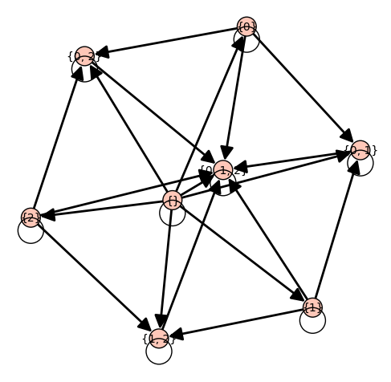

```python
g.show(figsize=[5,10])# El grafo es muy grande por lo cual se ocultó la imagen
```

Para verificar las propiedades se puede usar el conjunto por extension, la matriz (que sea triangular superior y con unos en la diagonal), o el grafo. La última representación es muy útil para verificar la transitividad.

### Punto 7:

🇺🇸 Give an example of the relation: "Let $D$ be the relation on $\mathbb{N}$ defined by $a D b$ if and only if $a$ divides $b$, for all $a, b \in \mathbb{N}$", which is express in terms of sets as:

$$D=\left\{\left(a,b\right):b\% a=0\right\}.$$

With the example determine if the relation is reflexive, symmetric, skew-symmetric and /or transitive.

🇨🇴 De un ejemplo de la relación "Sea $D$ una relación sobre $\mathbb{N}$ definida por $a D b$ si y solo si $a$ divide a $b$, para todo $a$ y $ b \in \mathbb{N}$", la cual, por comprensión, se expresa como:

$$D=\left\{\left(a,b\right):b\% a=0\right\}.$$

Con el ejemplo determine si la relación es replexiva, simétrica, antisimétrica o transitiva.

**Solución:**

1. Dems $X=\{1,2,3,4,5,6\}$ y hallemos la relación $D$ sobre $X$.

```python
X=[1,2,3,4,5,6]
D=[(i,j) for i in X for j in X if j%i==0] #Lista por comprensión que compacta un for
print(D)
```

```
[(1, 1), (1, 2), (1, 3), (1, 4), (1, 5), (1, 6), (2, 2), (2, 4), (2, 6), (3, 3), (3, 6), (4, 4), (5, 5), (6, 6)]
```

1. Verifiqyemos las propiedades que cumple usando un grafo:

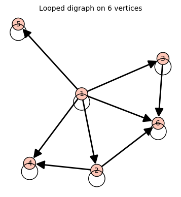

```python
g=DiGraph(loops=True)
g.add_vertices(X)
g.add_edges(D)
g
```

Es posible ver que la relación es reflexiva (exiten loops en cada una de las aristas) y antisimétrica (cada fleya tiene una sola dirección). No es simétrica porque cada aríata tiene una sola flecha. Además, es transitiva por que para ir de 1 a 4 hay dos camisnos, para ir de 1 a 6 hay dos caminos y para ir de pasando por 2 y dos caminos pasando por 3.

Por lo tanto, la relación es reflexiva, antisimétrica y transitiva.

### Punto 8:

🇺🇸 Let $X=\{\text{San Francisco}, \text{Pittsburg},\text{Chicago}, \text{San Diego}, \text{Filadelphia}, \text{Los Ángeles}\}$ be a set, and let $R$ be a relation over $X$ such that $xRy$ if and only if $x$ and $y$ are in the same stated.

1. Is $R$ an equivalence relation? Justify you answer.
2. Write the quotient set given by the relation.

🇨🇴 Sea $X=\{\text{San Francisco (SF)}, \text{Pittsburg (P)},\text{Chicago (C)}, \text{San Diego (SD)}, \text{Filadelphia (F)}, \text{Los Ángeles (LA)}\}$ un conjunto, y sea $R$ una relación sobre $X$ tal que $xRy$ si y solo si $x$ y $y$ estan el mismo estado.

1. ¿Es $R$ una relación de equivalencia? Justifique su respuesta.
2. Escriba el conjunto cociente dado por la relación.

**Solución:**

Determinemos qué ciudad está en cuál estado y formemos los respectivos conjuntos:

- $CA=\{x:x \text{ es ciudad del estado de California}\}=\{\text{SF},\text{SD},\text{LA}\}$,
- $PE=\{x:x \text{ es ciudad del estado de Pensilvania}\}=\{\text{P},\text{F}\}$,
- $I=\{x:x \text{ es ciudad del estado de Ilinois}\}=\{\text{C},\}$.

A simple vista los conjuntos $CA$, $PE$ e $I$ son una partición del conjunto $X$, por lo tanto la relación $R$ es de equivalencia.

Como añadidura, para que se vea más claro el hecho anterior se generará el conjunto de parejas ordenadas con su respectiva matriz y grafo, y con esto verificar la conclusión anterior.

```python
#Estos pasos serán explicados de forma explícita en elpunto 9
C1=set([(i,j) for i in ['SF','SD','LA'] for j in ['SF','SD','LA']])
C2=set([(i,j) for i in ['P','F'] for j in ['P','F']])
C3=set([(i,j) for i in ['C'] for j in ['C']])
R=C1.union(C2.union(C3))
print(R)
```

```
{('SD', 'SF'), ('F', 'P'), ('C', 'C'), ('SD', 'SD'), ('F', 'F'), ('SF', 'SD'), ('SD', 'LA'), ('SF', 'SF'), ('LA', 'LA'), ('P', 'P'), ('LA', 'SD'), ('SF', 'LA'), ('LA', 'SF'), ('P', 'F')}
```

```python
M = matrix([[1,0,0,1,0,1],[0,1,0,0,1,0],[0,0,1,0,0,0],[1,0,0,1,0,1],[0,1,0,0,1,0],[1,0,0,1,0,1]])
show(M)
```

$$\newcommand{\Bold}[1]{\mathbf{#1}}\left(\begin{array}{rrrrrr}
1 & 0 & 0 & 1 & 0 & 1 \\
0 & 1 & 0 & 0 & 1 & 0 \\
0 & 0 & 1 & 0 & 0 & 0 \\
1 & 0 & 0 & 1 & 0 & 1 \\
0 & 1 & 0 & 0 & 1 & 0 \\
1 & 0 & 0 & 1 & 0 & 1
\end{array}\right)$$

- En la matriz: Tiene las ciudades en el orden que se muestran en el conjunto $X$ por extensión, para las finalas y las columnas. Ahoram la relación es reflexiva porque la diagonal tiene unos, es simétrica porque la matriz es simétrica, y la trancitividad veamosla con mayor claridad en el grafo.

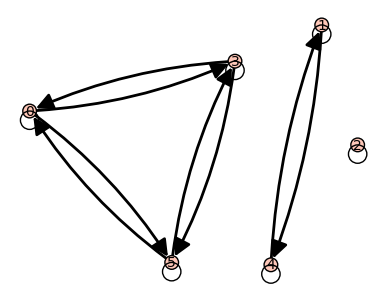

```python
g4 = DiGraph(M)
show(g4)
```

- Grafo: Aqui el conjunto $\{0,3,5\}$ corres ponde con el conjunto $CA$, el conjunto $\{4,1\}$ con el conjunto $PE$ y el conjunto $\{2\}$ con $I$. Entonces, la relación es transitiva por que es posible en los tres grafos, cada uno por separado ir de un punto a otro sin inconvennientes en cualquier dirección. Además, es reflexiva porque cada arista tiene bucle, y es simétrica porque entre dos vertices hay siempre dos aristas en direcciones opiestas.

### Punto 9:

🇺🇸 List all order pairs, and give an example of an equivalence relation over $A=\{a,b,c,d,e,f\}$ which has a three size quotient set $(|A/\sim|=3)$.

🇨🇴 Liste todas las parejas ordenadas dando un ejemplo de una relación de equivalencia sobre el conjunto $A=\{a,b,c,d,e,f\}$, el cual tenga un conjunto cociente de tamaño 3, es decir, $|A/\sim|=3$.

**Solución:**

Primero, se halla el conjunto de partes de $A$ y de el se toma una patición que cumpla tener 3 elementos, por ejemplos, $\{\{e,a\};\{c,d\};\{b,f\}\}$, y con ella construimos la siguiente relación $\{\{e,a\}\times \{e,a\};\{c,d\}\times \{c,d\};\{b,f\}\times \{b,f\}\}$, que por extensión es:

$$\{(e, a), (f, b), (c, d), (b, f), (c, c), (a, a), (b, b), (f, f), (d, d), (e, e), (a, e), (d, c)\}.$$

Finalmente, concluimos que es de equivalencia por los teoremas vistos en clase.

Como adicional, dejo los códigos para hacer este proceso en SageMath.

```python
#Hallemos partes de A
PA=set(Subsets(set(['a','b','c','d','e','f'])))
print(PA)
```

```
{{'c', 'f', 'e', 'a'}, {'d', 'a', 'c', 'e', 'f'}, {'b', 'f'}, {'b'}, {'e'}, {'c'}, {'f', 'e'}, {'c', 'a', 'd'}, {'e', 'a', 'd'}, {'c', 'f', 'a', 'd'}, {'b', 'c', 'e'}, {'f', 'e', 'a'}, {'b', 'c', 'a'}, {'b', 'e', 'a'}, {'b', 'f', 'e', 'd'}, {'b', 'c'}, {'b', 'e'}, {'b', 'e', 'd'}, {'f'}, {'b', 'a', …
```

```python
#Lista de todas las parejas ordenadas usando listas por comprension
C1=set([(i,j) for i in ['a','e'] for j in ['a','e']]) # la primera clase de equivalencia de la partición
C2=set([(i,j) for i in ['c','d'] for j in ['c','d']]) # la segunda clase de equivalencia de la partición
C3=set([(i,j) for i in ['b','f'] for j in ['b','f']]) # la tercera clase de equivalencia de la partición
print(C1)
print()
print(C2)
print()
print(C3)
```

```
{('e', 'a'), ('a', 'e'), ('e', 'e'), ('a', 'a')}

{('c', 'd'), ('c', 'c'), ('d', 'c'), ('d', 'd')}

{('f', 'b'), ('b', 'f'), ('b', 'b'), ('f', 'f')}
```

```python
#Unión de las tres clases para generar la relación
R=C1.union(C2.union(C3))
print(R)
```

```
{('e', 'a'), ('f', 'b'), ('c', 'd'), ('b', 'f'), ('c', 'c'), ('a', 'a'), ('b', 'b'), ('f', 'f'), ('d', 'd'), ('e', 'e'), ('a', 'e'), ('d', 'c')}
```

### Punto 10:

🇺🇸 Let $A = \{a, b, c\}$. Then $\tau_A = \{A/\sim_1 , A/\sim_2 , A/\sim_3\}$ be the set of partitions of the set $A$, where

- $A/\sim_1 = \{\{a\}, \{b\}, \{c\}\},$
- $A/\sim_2= \{\{b, c\}, \{a\}\},$
- $A/\sim_3=\{\{a,b,c\}\}.$

Also, we see that $E(A) = \{R_1 , R_2 , R_3, R_4 \}$ be the set of equivalence relations on $A$, where these are defined by the sets:

- $R_1 = \left\lbrace (a, a); (b, b); (c, c); (a, b); (b, a)\right\rbrace$,
- $R_2 = \left\lbrace(a, a); (b, b); (c, c)\right\rbrace$,
- $R_3=\left\lbrace(a, a); (b, b); (c,c); (b, c); (c, b)\right\rbrace$,
- $R_4=\left\lbrace \left(a,a\right); \left(b,b\right);\left(c,c\right);\left(a,c\right);\left(c,a\right)\right\rbrace$.

Now, with the last information follow step by step the following points:

1. Write in enumerated form the set $\mathcal{P}\left(A\right)$.
2. Verify if the set $\tau_A$ has all possible partitions of $A$, if it has not complete the set.
3. Based on $\left(ii.\right)$ verify if the set $E(A)$ is the set of all possible equivalence relations of the set $A$, if it is not complete the set.
4. Finally, write from the sets $\tau_A$ and $E(A)$ the correspondence between their elements.

🇨🇴 Sea $A = \{a, b, c\}$. Then $\tau_A = \{A/\sim_1 , A/\sim_2 , A/\sim_3\}$ un conjunto de particiones de $A$, con

- $A/\sim_1 = \{\{a\}, \{b\}, \{c\}\},$
- $A/\sim_2= \{\{b, c\}, \{a\}\},$
- $A/\sim_3=\{\{a,b,c\}\}.$

También, sea $E(A) = \{R_1 , R_2 , R_3, R_4 \}$ el conjunto de relaciones de equivalencia sobre $A$, las cuales estan definidas por los siguientes conjuntos:

- $R_1 = \left\lbrace (a, a); (b, b); (c, c); (a, b); (b, a)\right\rbrace$,
- $R_2 = \left\lbrace(a, a); (b, b); (c, c)\right\rbrace$,
- $R_3=\left\lbrace(a, a); (b, b); (c,c); (b, c); (c, b)\right\rbrace$,
- $R_4=\left\lbrace \left(a,a\right); \left(b,b\right);\left(c,c\right);\left(a,c\right);\left(c,a\right)\right\rbrace$.

Ahora, con la información, antes presentada, siga los siguientes pasos:

1. Escriba por extensión el siguiente conjunto $\mathcal{P}\left(A\right)$.
2. Verifique si el conjunto $\tau_A$ tiene todas las posibles particones de $A$. Si no es así, complete el conjunto.
3. Con base en $\left(2.\right)$ verifique si el conjunto $E(A)$ tiene todas las posibles relaciones de equivalencia sobre $A$. Si no es así, complete el conjunto.
4. Finalmente, Escriba de los conjuntos $\tau_A$ y $E(A)$ la correspondencia entre sus elementos.

**Solución:**

```python
#Parte 1. Conjunto de partes
A=set(['a','b','c'])
PA=Set(Subsets(A))
print(PA)
```

```
{{'a'}, {'b'}, {'c'}, {'b', 'c', 'a'}, {'b', 'c'}, {}, {'c', 'a'}, {'b', 'a'}}
```

Para la parte 2. Se puede ver que hacen falta los siguientes conjuntos en $\tau(A)$:

- $A/\sim_4= \{\{a, c\}, \{b\}\},$
- $A/\sim_5= \{\{a, b\}, \{c\}\},$

Por el enunciado y la parte 2 tenemos que todas las posibles particones del conjunto $A$ son:

- $A/\sim_1 = \{\{a\}, \{b\}, \{c\}\},$ que genera una relación de la siguiente forma $R=\{\{a\}\times \{a\}, \{b\}\times \{b\}, \{c\}\times \{ c\}\}$ es decir, tiene tres parejas ordenadas, y corres ponde con $R_2 = \left\lbrace(a, a); (b, b); (c, c)\right\rbrace$.
- $A/\sim_2= \{\{b, c\}, \{a\}\},$ que genera una relación de la siguiente forma $R= \{\{b, c\}\times \{b, c\}, \{a\} \times \{a\}\},$ es decir, tiene cinco parejas ordenadas, y corres ponde con $R_3=\left\lbrace(a, a); (b, b); (c,c); (b, c); (c, b)\right\rbrace$.
- $A/\sim_3=\{\{a,b,c\}\},$ que genera una relación de la siguiente forma $R=\{\{a,b,c\}\times \{a,b,c\}\},$ es decir, tiene nueve parejas ordenadas y esta relación no está en $E(A)$.
- $A/\sim_4= \{\{a, c\}, \{b\}\},$ que genera una relación de la siguiente forma $R= \{\{a, c\}\times \{a, c\}, \{b\} \times \{b\}\},$ es decir, tiene cinco parejas ordenadas, y corres ponde con $R_4=\left\lbrace \left(a,a\right); \left(b,b\right);\left(c,c\right);\left(a,c\right);\left(c,a\right)\right\rbrace$.
- $A/\sim_5= \{\{a, b\}, \{c\}\},$ que genera una relación de la siguiente forma $R= \{\{b, a\}\times \{b, a\}, \{c\} \times \{c\}\},$ es decir, tiene cinco parejas ordenadas, y corres ponde con $R_1 = \left\lbrace (a, a); (b, b); (c, c); (a, b); (b, a)\right\rbrace$.

La relación faltente es:

- $R_5 = \left\lbrace (a, a); (b, b); (c, c); (a, b); (b, a); (b, c); (c, b);\left(a,c\right);\left(c,a\right)\right\rbrace$

Que viene de $A/\sim_3$.

De esta forma se estabéció la corres pondencia entre los elementos de $\tau_A$ y $E(A)$.